# IndianPIMA_Diabetes

**Diabetes Prediction**

Diabetes, is a group of metabolic disorders in which there are high blood sugar levels over a prolonged period. Symptoms of high blood sugar include frequent urination, increased thirst, and increased hunger. If left untreated, diabetes can cause many complications. Acute complications can include diabetic ketoacidosis, hyperosmolar hyperglycemic state, or death. Serious long-term complications include cardiovascular disease, stroke, chronic kidney disease, foot ulcers, and damage to the eyes.This dataset is originally from the National Institute of Diabetes and Digestive and Kidney Diseases. The objective of the dataset is to diagnostically predict whether or not a patient has diabetes, based on certain diagnostic measurements included in the dataset. Several constraints were placed on the selection of these instances from a larger database. In particular, all patients here are females at least 21 years old of Pima Indian heritage.

**Objective**

**Data**

The datasets consists of several medical predictor variables and one target variable, Outcome. Predictor variables includes the number of pregnancies the patient has had, their BMI, insulin level, age, and so on.

**Pregnancies:** Number of times pregnant

**Glucose:** Plasma glucose concentration a 2 hours in an oral glucose tolerance test

**BloodPressure:** Diastolic blood pressure (mm Hg)

**SkinThickness:** Triceps skin fold thickness (mm)

**Insulin:** 2-Hour serum insulin (mu U/ml)

**BMI:** Body mass index (weight in kg/(height in m)^2)

**DiabetesPedigreeFunction:** Diabetes pedigree function

**Age:**Age (years)

**Outcome:** Class variable (0 or 1)

```python
import numpy as np
import pandas as pd
import seaborn as sns
import matplotlib.pyplot as plt
diabetes = pd.read_csv('diabetes.csv')

diabetes
```

|  | Pregnancies | Glucose | BloodPressure | SkinThickness | Insulin | BMI | DiabetesPedigreeFunction | Age | Outcome |
| --- | --- | --- | --- | --- | --- | --- | --- | --- | --- |
| 0 | 6 | 148 | 72 | 35 | 0 | 33.6 | 0.627 | 50 | 1 |
| 1 | 1 | 85 | 66 | 29 | 0 | 26.6 | 0.351 | 31 | 0 |
| 2 | 8 | 183 | 64 | 0 | 0 | 23.3 | 0.672 | 32 | 1 |
| 3 | 1 | 89 | 66 | 23 | 94 | 28.1 | 0.167 | 21 | 0 |
| 4 | 0 | 137 | 40 | 35 | 168 | 43.1 | 2.288 | 33 | 1 |
| 5 | 5 | 116 | 74 | 0 | 0 | 25.6 | 0.201 | 30 | 0 |
| 6 | 3 | 78 | 50 | 32 | 88 | 31.0 | 0.248 | 26 | 1 |
| 7 | 10 | 115 | 0 | 0 | 0 | 35.3 | 0.134 | 29 | 0 |
| 8 | 2 | 197 | 70 | 45 | 543 | 30.5 | 0.158 | 53 | 1 |
| 9 | 8 | 125 | 96 | 0 | 0 | 0.0 | 0.232 | 54 | 1 |
| 10 | 4 | 110 | 92 | 0 | 0 | 37.6 | 0.191 | 30 | 0 |
| 11 | 10 | 168 | 74 | 0 | 0 | 38.0 | 0.537 | 34 | 1 |
| 12 | 10 | 139 | 80 | 0 | 0 | 27.1 | 1.441 | 57 | 0 |
| 13 | 1 | 189 | 60 | 23 | 846 | 30.1 | 0.398 | 59 | 1 |
| 14 | 5 | 166 | 72 | 19 | 175 | 25.8 | 0.587 | 51 | 1 |
| 15 | 7 | 100 | 0 | 0 | 0 | 30.0 | 0.484 | 32 | 1 |
| 16 | 0 | 118 | 84 | 47 | 230 | 45.8 | 0.551 | 31 | 1 |
| 17 | 7 | 107 | 74 | 0 | 0 | 29.6 | 0.254 | 31 | 1 |
| 18 | 1 | 103 | 30 | 38 | 83 | 43.3 | 0.183 | 33 | 0 |
| 19 | 1 | 115 | 70 | 30 | 96 | 34.6 | 0.529 | 32 | 1 |
| 20 | 3 | 126 | 88 | 41 | 235 | 39.3 | 0.704 | 27 | 0 |
| 21 | 8 | 99 | 84 | 0 | 0 | 35.4 | 0.388 | 50 | 0 |
| 22 | 7 | 196 | 90 | 0 | 0 | 39.8 | 0.451 | 41 | 1 |
| 23 | 9 | 119 | 80 | 35 | 0 | 29.0 | 0.263 | 29 | 1 |
| 24 | 11 | 143 | 94 | 33 | 146 | 36.6 | 0.254 | 51 | 1 |
| 25 | 10 | 125 | 70 | 26 | 115 | 31.1 | 0.205 | 41 | 1 |
| 26 | 7 | 147 | 76 | 0 | 0 | 39.4 | 0.257 | 43 | 1 |
| 27 | 1 | 97 | 66 | 15 | 140 | 23.2 | 0.487 | 22 | 0 |
| 28 | 13 | 145 | 82 | 19 | 110 | 22.2 | 0.245 | 57 | 0 |
| 29 | 5 | 117 | 92 | 0 | 0 | 34.1 | 0.337 | 38 | 0 |
| ... | ... | ... | ... | ... | ... | ... | ... | ... | ... |
| 738 | 2 | 99 | 60 | 17 | 160 | 36.6 | 0.453 | 21 | 0 |
| 739 | 1 | 102 | 74 | 0 | 0 | 39.5 | 0.293 | 42 | 1 |
| 740 | 11 | 120 | 80 | 37 | 150 | 42.3 | 0.785 | 48 | 1 |
| 741 | 3 | 102 | 44 | 20 | 94 | 30.8 | 0.400 | 26 | 0 |
| 742 | 1 | 109 | 58 | 18 | 116 | 28.5 | 0.219 | 22 | 0 |
| 743 | 9 | 140 | 94 | 0 | 0 | 32.7 | 0.734 | 45 | 1 |
| 744 | 13 | 153 | 88 | 37 | 140 | 40.6 | 1.174 | 39 | 0 |
| 745 | 12 | 100 | 84 | 33 | 105 | 30.0 | 0.488 | 46 | 0 |
| 746 | 1 | 147 | 94 | 41 | 0 | 49.3 | 0.358 | 27 | 1 |
| 747 | 1 | 81 | 74 | 41 | 57 | 46.3 | 1.096 | 32 | 0 |
| 748 | 3 | 187 | 70 | 22 | 200 | 36.4 | 0.408 | 36 | 1 |
| 749 | 6 | 162 | 62 | 0 | 0 | 24.3 | 0.178 | 50 | 1 |
| 750 | 4 | 136 | 70 | 0 | 0 | 31.2 | 1.182 | 22 | 1 |
| 751 | 1 | 121 | 78 | 39 | 74 | 39.0 | 0.261 | 28 | 0 |
| 752 | 3 | 108 | 62 | 24 | 0 | 26.0 | 0.223 | 25 | 0 |
| 753 | 0 | 181 | 88 | 44 | 510 | 43.3 | 0.222 | 26 | 1 |
| 754 | 8 | 154 | 78 | 32 | 0 | 32.4 | 0.443 | 45 | 1 |
| 755 | 1 | 128 | 88 | 39 | 110 | 36.5 | 1.057 | 37 | 1 |
| 756 | 7 | 137 | 90 | 41 | 0 | 32.0 | 0.391 | 39 | 0 |
| 757 | 0 | 123 | 72 | 0 | 0 | 36.3 | 0.258 | 52 | 1 |
| 758 | 1 | 106 | 76 | 0 | 0 | 37.5 | 0.197 | 26 | 0 |
| 759 | 6 | 190 | 92 | 0 | 0 | 35.5 | 0.278 | 66 | 1 |
| 760 | 2 | 88 | 58 | 26 | 16 | 28.4 | 0.766 | 22 | 0 |
| 761 | 9 | 170 | 74 | 31 | 0 | 44.0 | 0.403 | 43 | 1 |
| 762 | 9 | 89 | 62 | 0 | 0 | 22.5 | 0.142 | 33 | 0 |
| 763 | 10 | 101 | 76 | 48 | 180 | 32.9 | 0.171 | 63 | 0 |
| 764 | 2 | 122 | 70 | 27 | 0 | 36.8 | 0.340 | 27 | 0 |
| 765 | 5 | 121 | 72 | 23 | 112 | 26.2 | 0.245 | 30 | 0 |
| 766 | 1 | 126 | 60 | 0 | 0 | 30.1 | 0.349 | 47 | 1 |
| 767 | 1 | 93 | 70 | 31 | 0 | 30.4 | 0.315 | 23 | 0 |

768 rows × 9 columns

**First 6 samples**

```python
first = diabetes.head(6)
first
```

|  | Pregnancies | Glucose | BloodPressure | SkinThickness | Insulin | BMI | DiabetesPedigreeFunction | Age | Outcome |
| --- | --- | --- | --- | --- | --- | --- | --- | --- | --- |
| 0 | 6 | 148 | 72 | 35 | 0 | 33.6 | 0.627 | 50 | 1 |
| 1 | 1 | 85 | 66 | 29 | 0 | 26.6 | 0.351 | 31 | 0 |
| 2 | 8 | 183 | 64 | 0 | 0 | 23.3 | 0.672 | 32 | 1 |
| 3 | 1 | 89 | 66 | 23 | 94 | 28.1 | 0.167 | 21 | 0 |
| 4 | 0 | 137 | 40 | 35 | 168 | 43.1 | 2.288 | 33 | 1 |
| 5 | 5 | 116 | 74 | 0 | 0 | 25.6 | 0.201 | 30 | 0 |

**Last 7 samples**

```python
last = diabetes.tail(7)
last
```

|  | Pregnancies | Glucose | BloodPressure | SkinThickness | Insulin | BMI | DiabetesPedigreeFunction | Age | Outcome |
| --- | --- | --- | --- | --- | --- | --- | --- | --- | --- |
| 761 | 9 | 170 | 74 | 31 | 0 | 44.0 | 0.403 | 43 | 1 |
| 762 | 9 | 89 | 62 | 0 | 0 | 22.5 | 0.142 | 33 | 0 |
| 763 | 10 | 101 | 76 | 48 | 180 | 32.9 | 0.171 | 63 | 0 |
| 764 | 2 | 122 | 70 | 27 | 0 | 36.8 | 0.340 | 27 | 0 |
| 765 | 5 | 121 | 72 | 23 | 112 | 26.2 | 0.245 | 30 | 0 |
| 766 | 1 | 126 | 60 | 0 | 0 | 30.1 | 0.349 | 47 | 1 |
| 767 | 1 | 93 | 70 | 31 | 0 | 30.4 | 0.315 | 23 | 0 |

**Summary/Quick overview of the Dataset**

```python
diabetes.info()
```

```
<class 'pandas.core.frame.DataFrame'>
RangeIndex: 768 entries, 0 to 767
Data columns (total 9 columns):
Pregnancies                 768 non-null int64
Glucose                     768 non-null int64
BloodPressure               768 non-null int64
SkinThickness               768 non-null int64
Insulin                     768 non-null int64
BMI                         768 non-null float64
DiabetesPedigreeFunction    768 non-null float64
Age                         768 non-null int64
Outcome                     768 non-null int64
dtypes: float64(2), int64(7)
memory usage: 54.1 KB
```

**Transpose Diabetes Data**

```python
diabetes.transpose()
```

|  | 0 | 1 | 2 | 3 | 4 | 5 | 6 | 7 | 8 | 9 | ... | 758 | 759 | 760 | 761 | 762 | 763 | 764 | 765 | 766 | 767 |
| --- | --- | --- | --- | --- | --- | --- | --- | --- | --- | --- | --- | --- | --- | --- | --- | --- | --- | --- | --- | --- | --- |
| Pregnancies | 6.000 | 1.000 | 8.000 | 1.000 | 0.000 | 5.000 | 3.000 | 10.000 | 2.000 | 8.000 | ... | 1.000 | 6.000 | 2.000 | 9.000 | 9.000 | 10.000 | 2.00 | 5.000 | 1.000 | 1.000 |
| Glucose | 148.000 | 85.000 | 183.000 | 89.000 | 137.000 | 116.000 | 78.000 | 115.000 | 197.000 | 125.000 | ... | 106.000 | 190.000 | 88.000 | 170.000 | 89.000 | 101.000 | 122.00 | 121.000 | 126.000 | 93.000 |
| BloodPressure | 72.000 | 66.000 | 64.000 | 66.000 | 40.000 | 74.000 | 50.000 | 0.000 | 70.000 | 96.000 | ... | 76.000 | 92.000 | 58.000 | 74.000 | 62.000 | 76.000 | 70.00 | 72.000 | 60.000 | 70.000 |
| SkinThickness | 35.000 | 29.000 | 0.000 | 23.000 | 35.000 | 0.000 | 32.000 | 0.000 | 45.000 | 0.000 | ... | 0.000 | 0.000 | 26.000 | 31.000 | 0.000 | 48.000 | 27.00 | 23.000 | 0.000 | 31.000 |
| Insulin | 0.000 | 0.000 | 0.000 | 94.000 | 168.000 | 0.000 | 88.000 | 0.000 | 543.000 | 0.000 | ... | 0.000 | 0.000 | 16.000 | 0.000 | 0.000 | 180.000 | 0.00 | 112.000 | 0.000 | 0.000 |
| BMI | 33.600 | 26.600 | 23.300 | 28.100 | 43.100 | 25.600 | 31.000 | 35.300 | 30.500 | 0.000 | ... | 37.500 | 35.500 | 28.400 | 44.000 | 22.500 | 32.900 | 36.80 | 26.200 | 30.100 | 30.400 |
| DiabetesPedigreeFunction | 0.627 | 0.351 | 0.672 | 0.167 | 2.288 | 0.201 | 0.248 | 0.134 | 0.158 | 0.232 | ... | 0.197 | 0.278 | 0.766 | 0.403 | 0.142 | 0.171 | 0.34 | 0.245 | 0.349 | 0.315 |
| Age | 50.000 | 31.000 | 32.000 | 21.000 | 33.000 | 30.000 | 26.000 | 29.000 | 53.000 | 54.000 | ... | 26.000 | 66.000 | 22.000 | 43.000 | 33.000 | 63.000 | 27.00 | 30.000 | 47.000 | 23.000 |
| Outcome | 1.000 | 0.000 | 1.000 | 0.000 | 1.000 | 0.000 | 1.000 | 0.000 | 1.000 | 1.000 | ... | 0.000 | 1.000 | 0.000 | 1.000 | 0.000 | 0.000 | 0.00 | 0.000 | 1.000 | 0.000 |

9 rows × 768 columns

**Point Five Summary**

```python
diabetes.describe()
```

|  | Pregnancies | Glucose | BloodPressure | SkinThickness | Insulin | BMI | DiabetesPedigreeFunction | Age | Outcome |
| --- | --- | --- | --- | --- | --- | --- | --- | --- | --- |
| count | 768.000000 | 768.000000 | 768.000000 | 768.000000 | 768.000000 | 768.000000 | 768.000000 | 768.000000 | 768.000000 |
| mean | 3.845052 | 120.894531 | 69.105469 | 20.536458 | 79.799479 | 31.992578 | 0.471876 | 33.240885 | 0.348958 |
| std | 3.369578 | 31.972618 | 19.355807 | 15.952218 | 115.244002 | 7.884160 | 0.331329 | 11.760232 | 0.476951 |
| min | 0.000000 | 0.000000 | 0.000000 | 0.000000 | 0.000000 | 0.000000 | 0.078000 | 21.000000 | 0.000000 |
| 25% | 1.000000 | 99.000000 | 62.000000 | 0.000000 | 0.000000 | 27.300000 | 0.243750 | 24.000000 | 0.000000 |
| 50% | 3.000000 | 117.000000 | 72.000000 | 23.000000 | 30.500000 | 32.000000 | 0.372500 | 29.000000 | 0.000000 |
| 75% | 6.000000 | 140.250000 | 80.000000 | 32.000000 | 127.250000 | 36.600000 | 0.626250 | 41.000000 | 1.000000 |
| max | 17.000000 | 199.000000 | 122.000000 | 99.000000 | 846.000000 | 67.100000 | 2.420000 | 81.000000 | 1.000000 |

**Data Visualization**

**Distribution of Diabetes**

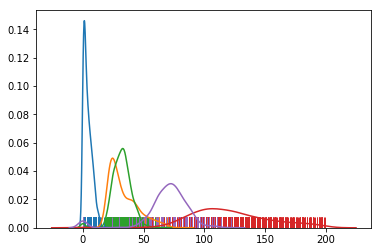

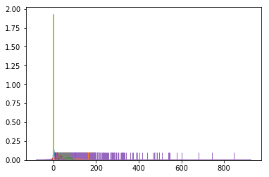

```python
sns.distplot(diabetes[['Pregnancies']], hist=False, rug=True)
sns.distplot(diabetes[['Age']], hist=False, rug=True)
sns.distplot(diabetes[['BMI']], hist=False, rug=True)
sns.distplot(diabetes[['Glucose']], hist=False, rug=True)
sns.distplot(diabetes[['BloodPressure']], hist=False, rug=True)
plt.show()
for col in diabetes.columns:
  sns.distplot(diabetes[[col]], hist=False, rug=True)
```

**Histogram**

Plotting for all columns to predict Diabetes

```
Plotting for column Pregnancies
```

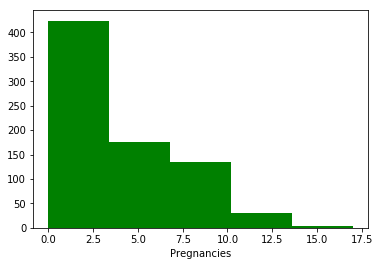

```
Plotting for column Glucose
```

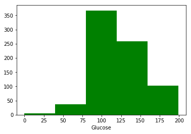

```
Plotting for column BloodPressure
```

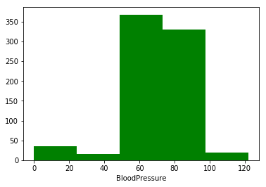

```
Plotting for column SkinThickness
```

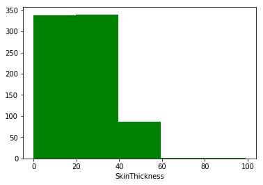

```
Plotting for column Insulin
```

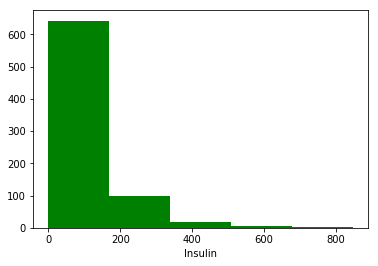

```
Plotting for column BMI
```

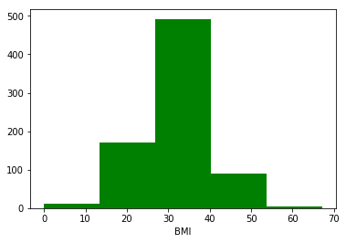

```
Plotting for column DiabetesPedigreeFunction
```

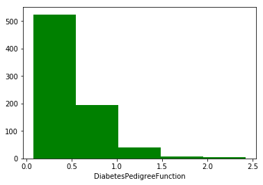

```
Plotting for column Age
```

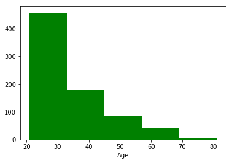

```
Plotting for column Outcome
```

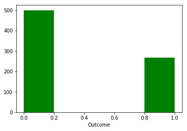

```python
for col in diabetes.columns:
    plt.hist(diabetes[col], 5, facecolor='green')
    #hist = diabetes[col].hist(bins=10)
    plt.xlabel(col)

    print("Plotting for column {}".format(col))
    plt.show()
```

**Histogram - Group by Outcome**

```
Outcome
0    [[AxesSubplot(0.125,0.670278;0.215278x0.209722...
1    [[AxesSubplot(0.125,0.670278;0.215278x0.209722...
dtype: object
```

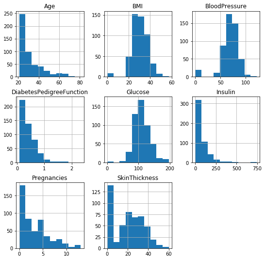

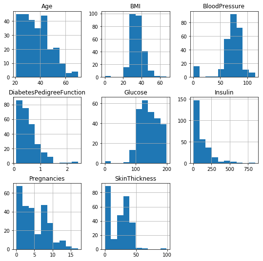

```python
diabetes.groupby('Outcome').hist(figsize=(9, 9))
```

**Comparison of BMI and Pregnancies against the Outcome of Diabetes**

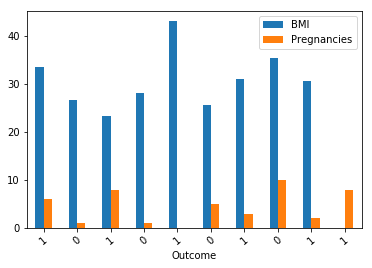

```python
diabetes = diabetes.head(10)
fig, ax = plt.subplots()
diabetes.plot.bar(x = 'Outcome', y = ['BMI', 'Pregnancies'], rot = 40, ax = ax)
plt.show()
```

**Checking for Null Values in Diabetes Data**

```python
diabetes.isnull().values.any() #looks like we don't have any nulls
```

```
False
```

**Box Plotting for different attributes and Outliers**

```
array([<matplotlib.axes._subplots.AxesSubplot object at 0x0000022814AACD30>,
      dtype=object)
```

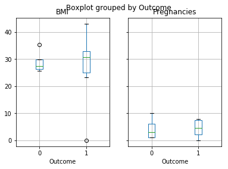

```python
diabetes.boxplot(by ='Outcome', column =['BMI','Pregnancies'], grid = True)
```

```
array([<matplotlib.axes._subplots.AxesSubplot object at 0x0000022814F2EDA0>,
      dtype=object)
```

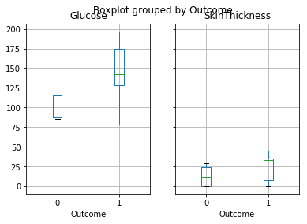

```python
diabetes.boxplot(by ='Outcome', column =['Glucose','SkinThickness'], grid = True)
```

```
array([<matplotlib.axes._subplots.AxesSubplot object at 0x0000022815000E80>,
      dtype=object)
```

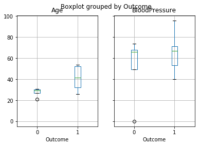

```python
diabetes.boxplot(by ='Outcome', column =['Age','BloodPressure'], grid = True)
```

```
array([<matplotlib.axes._subplots.AxesSubplot object at 0x0000022813277240>,
      dtype=object)
```

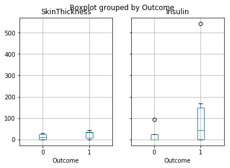

```python
diabetes.boxplot(by ='Outcome', column =['SkinThickness','Insulin'], grid = True)
```

**Scatter Plot for different parameters against the Outcome of Diabetes**

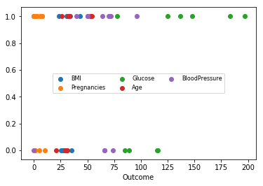

```python
plt.xlabel('Outcome')
bmi=plt.scatter(x=diabetes['BMI'], y=diabetes['Outcome'])
preg=plt.scatter(x=diabetes['Pregnancies'], y=diabetes['Outcome'])
gluc=plt.scatter(x=diabetes['Glucose'], y=diabetes['Outcome'])
age=plt.scatter(x=diabetes['Age'], y=diabetes['Outcome'])
bp=plt.scatter(x=diabetes['BloodPressure'], y=diabetes['Outcome'])
plt.legend((bmi,preg,gluc,age,bp),('BMI', 'Pregnancies', 'Glucose', 'Age', 'BloodPressure'),
           scatterpoints=1,
           loc='center',
           ncol=3,
           fontsize=8)

plt.show()
```

**Adding new columns - Finding logarthamic values for Age, Pragnancies and Insulin parameters**

log of Pregnancies and log of Insulin has Infinite values which are replaced by 0 to have a better visualization of data

```python
np.seterr(divide='ignore')
pd.set_option('mode.chained_assignment',None)
diabetes['log2_Age'] = np.log2(diabetes['Age'])
diabetes['log2_Insulin'] = np.log2(diabetes['Insulin'])
diabetes['log2_Pregnancies'] = np.log2(diabetes['Pregnancies'])
diabetes['log2_Insulin'] = diabetes['log2_Insulin'].replace([np.inf, -np.inf], 0)
diabetes['log2_Pregnancies'] = diabetes['log2_Pregnancies'].replace([np.inf, -np.inf], 0)
diabetes
```

|  | Pregnancies | Glucose | BloodPressure | SkinThickness | Insulin | BMI | DiabetesPedigreeFunction | Age | Outcome | log2_Age | log2_Insulin | log2_Pregnancies |
| --- | --- | --- | --- | --- | --- | --- | --- | --- | --- | --- | --- | --- |
| 0 | 6 | 148 | 72 | 35 | 0 | 33.6 | 0.627 | 50 | 1 | 5.643856 | 0.000000 | 2.584963 |
| 1 | 1 | 85 | 66 | 29 | 0 | 26.6 | 0.351 | 31 | 0 | 4.954196 | 0.000000 | 0.000000 |
| 2 | 8 | 183 | 64 | 0 | 0 | 23.3 | 0.672 | 32 | 1 | 5.000000 | 0.000000 | 3.000000 |
| 3 | 1 | 89 | 66 | 23 | 94 | 28.1 | 0.167 | 21 | 0 | 4.392317 | 6.554589 | 0.000000 |
| 4 | 0 | 137 | 40 | 35 | 168 | 43.1 | 2.288 | 33 | 1 | 5.044394 | 7.392317 | 0.000000 |
| 5 | 5 | 116 | 74 | 0 | 0 | 25.6 | 0.201 | 30 | 0 | 4.906891 | 0.000000 | 2.321928 |
| 6 | 3 | 78 | 50 | 32 | 88 | 31.0 | 0.248 | 26 | 1 | 4.700440 | 6.459432 | 1.584963 |
| 7 | 10 | 115 | 0 | 0 | 0 | 35.3 | 0.134 | 29 | 0 | 4.857981 | 0.000000 | 3.321928 |
| 8 | 2 | 197 | 70 | 45 | 543 | 30.5 | 0.158 | 53 | 1 | 5.727920 | 9.084808 | 1.000000 |
| 9 | 8 | 125 | 96 | 0 | 0 | 0.0 | 0.232 | 54 | 1 | 5.754888 | 0.000000 | 3.000000 |

**Scatter Plot for new parameters - log of Age, log of Insulin and log of Pregnancies parameters**

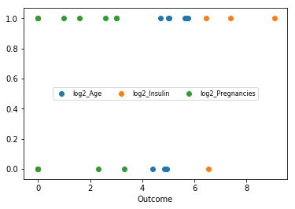

```python
plt.xlabel('Outcome')

log2_age=plt.scatter(x=diabetes['log2_Age'], y=diabetes['Outcome'])
log2_insulin=plt.scatter(x=diabetes['log2_Insulin'], y=diabetes['Outcome'])
log2_Pregnancies=plt.scatter(x=diabetes['log2_Pregnancies'], y=diabetes['Outcome'])
plt.legend((log2_age,log2_insulin,log2_Pregnancies),('log2_Age', 'log2_Insulin','log2_Pregnancies'),
           scatterpoints=1,
           loc='center',
           ncol=3,
           fontsize=8)

plt.show()
```

**Correlation features and Correlation plotting of different parameters of Diabetes**

|  | Pregnancies | Glucose | BloodPressure | SkinThickness | Insulin | BMI | DiabetesPedigreeFunction | Age | Outcome | log2_Age | log2_Insulin | log2_Pregnancies |
| --- | --- | --- | --- | --- | --- | --- | --- | --- | --- | --- | --- | --- |
| Pregnancies | 1.000000 | 0.223872 | -0.157293 | -0.754551 | -0.463945 | -0.398816 | -0.360170 | 0.225499 | 0.036860 | 0.247630 | -0.701923 | 0.967677 |
| Glucose | 0.223872 | 1.000000 | 0.160011 | 0.079469 | 0.514553 | 0.020703 | 0.193676 | 0.610445 | 0.559457 | 0.635244 | 0.096986 | 0.284225 |
| BloodPressure | -0.157293 | 0.160011 | 1.000000 | 0.048614 | 0.049254 | -0.671852 | -0.193327 | 0.490878 | 0.278445 | 0.449268 | -0.085431 | -0.058725 |
| SkinThickness | -0.754551 | 0.079469 | 0.048614 | 1.000000 | 0.637260 | 0.522803 | 0.283820 | 0.187328 | 0.330323 | 0.166306 | 0.699428 | -0.680473 |
| Insulin | -0.463945 | 0.514553 | 0.049254 | 0.637260 | 1.000000 | 0.257067 | 0.054212 | 0.359371 | 0.333250 | 0.328552 | 0.798148 | -0.397289 |
| BMI | -0.398816 | 0.020703 | -0.671852 | 0.522803 | 0.257067 | 1.000000 | 0.468276 | -0.391533 | -0.090966 | -0.352745 | 0.415300 | -0.386704 |
| DiabetesPedigreeFunction | -0.360170 | 0.193676 | -0.193327 | 0.283820 | 0.054212 | 0.468276 | 1.000000 | -0.032734 | 0.387560 | 0.024601 | 0.266327 | -0.345608 |
| Age | 0.225499 | 0.610445 | 0.490878 | 0.187328 | 0.359371 | -0.391533 | -0.032734 | 1.000000 | 0.590743 | 0.992069 | -0.066951 | 0.304337 |
| Outcome | 0.036860 | 0.559457 | 0.278445 | 0.330323 | 0.333250 | -0.090966 | 0.387560 | 0.590743 | 1.000000 | 0.598734 | 0.291329 | 0.172671 |
| log2_Age | 0.247630 | 0.635244 | 0.449268 | 0.166306 | 0.328552 | -0.352745 | 0.024601 | 0.992069 | 0.598734 | 1.000000 | -0.116858 | 0.329574 |
| log2_Insulin | -0.701923 | 0.096986 | -0.085431 | 0.699428 | 0.798148 | 0.415300 | 0.266327 | -0.066951 | 0.291329 | -0.116858 | 1.000000 | -0.644394 |
| log2_Pregnancies | 0.967677 | 0.284225 | -0.058725 | -0.680473 | -0.397289 | -0.386704 | -0.345608 | 0.304337 | 0.172671 | 0.329574 | -0.644394 | 1.000000 |

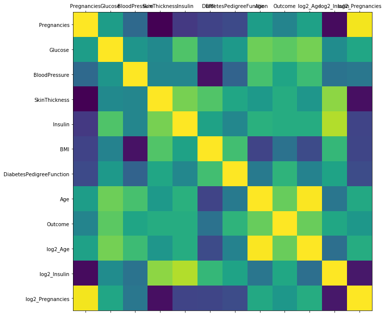

```python
 corr = diabetes.corr() # calling the correlation function on the datafrmae
 fig, ax = plt.subplots(figsize=(11,11))
 ax.matshow(corr) # color code the rectangles by correlation value
 plt.xticks(range(len(corr.columns)),corr.columns) # draw x tickmarks
 plt.yticks(range(len(corr.columns)),corr.columns) # draw y tickmarks
 corr
```

**Summary**

Out of 768 samples, 268 has diabetes and 500 does not have diabetes.

Age and log of Age seem to be correlated and same with Insulin and log of Insulin .

As the ratio of diabete to non diabetic predictions are not proportional , remedial actions like making equal proportions have to be made. For this techniques like Up Sampling / Down sampling should be used and data should be cleaned so that it gives more accurate results.